# Ecoton Quick Start Tutorial Lymph 5K

### installation

doesn't require scanpy! pip install . in the folder after git cloning the repository at https://github.com/pritykinlab/ecoton.git

```python
import pandas as pd
```

```python
import numpy as np
```

```python
import matplotlib.pyplot as plt
```

```python
import ecoton
```

## load transcripts, compute metatranscripts

load transcripts file (all you need to run ecoton)

```python
mytranscripts = pd.read_parquet('../spatial_5k/data/transcripts.parquet')
```

```python
pd.__version__
```

```
'2.3.1'
```

```python
ecoton.__version__
```

```
'0.3.1'
```

compute metatranscripts here:

```python
results = ecoton.ComputeMetatranscripts(
    mytranscripts, # loaded transcripts file from transcripts.parquet
    mode='xenium_5k' # or mode='xenium' for a limited panel. use ecoton.ComputeMetatranscripts? to see all the inputs / defaults
)
```

```
Mode: xenium_5k
[200/4602] genes | metatranscripts so far: 553,305
[400/4602] genes | metatranscripts so far: 1,284,210
[600/4602] genes | metatranscripts so far: 1,864,883
[800/4602] genes | metatranscripts so far: 2,391,558
[1000/4602] genes | metatranscripts so far: 2,841,163
[1200/4602] genes | metatranscripts so far: 3,282,882
[1400/4602] genes | metatranscripts so far: 3,743,282
[1600/4602] genes | metatranscripts so far: 3,914,491
[1800/4602] genes | metatranscripts so far: 4,073,494
[2000/4602] genes | metatranscripts so far: 4,210,857
[2200/4602] genes | metatranscripts so far: 4,375,806
[2400/4602] genes | metatranscripts so far: 4,532,917
[2600/4602] genes | metatranscripts so far: 4,662,411
[2800/4602] genes | metatranscripts so far: 4,783,044
[3000/4602] genes | metatranscripts so far: 4,880,072
[3200/4602] genes | metatranscripts so far: 4,985,713
[3400/4602] genes | metatranscripts so far: 5,026,647
[3600/4602] genes | metatranscripts so far: 5,059,160
[3800/4602] genes | metatranscripts so far: 5,098,692
[4000/4602] genes | metatranscripts so far: 5,113,106
[4200/4602] genes | metatranscripts so far: 5,118,679
[4400/4602] genes | metatranscripts so far: 5,120,718
[4600/4602] genes | metatranscripts so far: 5,121,417
```

```python
results['metatranscripts']
```

|  | feature_name | bin_x | bin_y | n | x_centroid | y_centroid | meta_id |
| --- | --- | --- | --- | --- | --- | --- | --- |
| 0 | AURKB | 92 | 408 | 3 | 737.411438 | 3266.005127 | 0 |
| 1 | AURKB | 90 | 419 | 3 | 724.234375 | 3355.229248 | 1 |
| 2 | AURKB | 92 | 413 | 4 | 740.210938 | 3310.621094 | 2 |
| 3 | AURKB | 91 | 414 | 3 | 732.973938 | 3317.942627 | 3 |
| 4 | AURKB | 92 | 414 | 3 | 738.307312 | 3315.807373 | 4 |
| ... | ... | ... | ... | ... | ... | ... | ... |
| 5121412 | REN | 200 | 243 | 5 | 1602.443726 | 1946.765625 | 5121412 |
| 5121413 | REN | 266 | 289 | 7 | 2131.975342 | 2315.718750 | 5121413 |
| 5121414 | REN | 480 | 96 | 3 | 3843.822998 | 770.276062 | 5121414 |
| 5121415 | REN | 480 | 583 | 3 | 3843.265625 | 4666.869629 | 5121415 |
| 5121416 | HRH3 | 593 | 417 | 3 | 4748.150879 | 3343.041748 | 5121416 |

5121417 rows × 7 columns

## compute the analytic null graph

determine which gene-gene colocalizations are higher than expected by chance

```python
analytic_response = ecoton.analytic_null_metatranscripts(results['metatranscripts'], verbose=True)
```

```
[analytic_null_metatranscripts] building edges from metadf using radius= 12.0
[analytic_null_metatranscripts] built 272807076 edges
[analytic_null_metatranscripts] total_transcripts=17680477.000, n_genes=4012
```

```
[analytic_null_metatranscripts] filtering applied: kept 2624852 / 3423179 gene pairs
[analytic_null_metatranscripts] building igraph using weight=Z
[analytic_null_metatranscripts] igraph: n_vertices=3997, n_edges=2623348
```

```python
G_ig = analytic_response[2]
```

## compute archetypes over the graph

determine gene-gene groups. multiple parameters here, num_archetypes (K), seed, run gene set enrichments, organism, also can compute graph centrality metrics.

The default archetypal cutoff threshold is 0.3. For sharp and layered tissues where less signature overlap is expected, such as brain data, we recommend increasing to 0.8.

```python
colocalization_response = ecoton.ProcessColocalizationGraph(G_ig = analytic_response[2], K=25, seed=1,
                                                            run_enrich=True,
                                                            organism='Human',)
```

```
→ Running Archetypal Analysis (K=25)...
Using NumPy backend
```

```python
colocalization_response['enrichment'][10]
```

|  | Gene_set | Term | Overlap | P-value | Adjusted P-value | Odds Ratio | Combined Score | Genes |
| --- | --- | --- | --- | --- | --- | --- | --- | --- |
| 0 | gs_ind_0 | GOBP_BLOOD_VESSEL_MORPHOGENESIS | 21/337 | 1.552091e-08 | 0.000037 | 5.783682 | 103.996834 | CLEC14A;SOX17;TBX2;EDN1;GJA5;PDGFB;ADAMTS1;SUL... |
| 1 | gs_ind_0 | GOBP_CIRCULATORY_SYSTEM_DEVELOPMENT | 26/545 | 4.615799e-08 | 0.000054 | 4.646044 | 78.477243 | CLEC14A;SOX17;TBX2;EDN1;PLN;GJA5;CACNA1C;PI16;... |
| 2 | gs_ind_0 | GOBP_TUBE_MORPHOGENESIS | 23/438 | 6.710628e-08 | 0.000054 | 4.914992 | 81.180859 | CLEC14A;SOX17;TBX2;EDN1;GJA5;PDGFB;ADAMTS1;POD... |
| 3 | gs_ind_0 | GOBP_ANIMAL_ORGAN_MORPHOGENESIS | 21/388 | 1.866090e-07 | 0.000084 | 4.910844 | 76.089850 | SOX17;TBX2;EDN1;GJA5;ALPL;ADAMTS1;IGF2;SULF1;M... |
| 4 | gs_ind_0 | GOBP_CIRCULATORY_SYSTEM_PROCESS | 17/258 | 2.383467e-07 | 0.000084 | 5.755805 | 87.773374 | SLC6A9;PDGFB;CASQ2;TBX2;EDN1;PLN;ELN;GJA5;EDNR... |
| 5 | gs_ind_0 | GOBP_VASCULATURE_DEVELOPMENT | 21/397 | 2.770509e-07 | 0.000084 | 4.781361 | 72.194076 | CLEC14A;SOX17;TBX2;EDN1;GJA5;PDGFB;ADAMTS1;SUL... |
| 6 | gs_ind_0 | GOBP_ANATOMICAL_STRUCTURE_FORMATION_INVOLVED_I... | 24/512 | 2.774489e-07 | 0.000084 | 4.376054 | 66.068045 | CLEC14A;SOX17;TBX2;EDN1;PLN;GJA5;PDGFB;ADAMTS1... |
| 7 | gs_ind_0 | GOBP_RENAL_FILTRATION | 6/19 | 2.784048e-07 | 0.000084 | 32.837037 | 495.648460 | PDGFB;EDN1;SULF1;GJA5;EDNRA;EMP2 |
| 8 | gs_ind_0 | GOBP_OUTFLOW_TRACT_MORPHOGENESIS | 8/46 | 3.940007e-07 | 0.000105 | 15.500293 | 228.581468 | SOX17;TBX2;JAG1;EDN1;ELN;GJA5;EDNRA;SOX18 |
| 9 | gs_ind_0 | GOBP_REGULATION_OF_SYSTEM_PROCESS | 16/240 | 5.005527e-07 | 0.000119 | 5.741250 | 83.291482 | PDGFB;CASQ2;TBX2;EDN1;PLN;TMEM100;GJA5;EDNRA;A... |
| 10 | gs_ind_0 | GOCC_EXTERNAL_ENCAPSULATING_STRUCTURE | 13/156 | 5.706748e-07 | 0.000119 | 7.063201 | 101.543726 | CLEC14A;PDGFB;ADAMTS1;TINAGL1;FBLN5;TGM2;ELN;S... |
| 11 | gs_ind_0 | GOBP_HEART_MORPHOGENESIS | 12/131 | 5.949196e-07 | 0.000119 | 7.749726 | 111.091077 | SOX17;ADAMTS1;TBX2;JAG1;EDN1;TMEM100;ELN;GJA5;... |
| 12 | gs_ind_0 | GOBP_STEM_CELL_FATE_COMMITMENT | 4/6 | 8.216619e-07 | 0.000152 | 118.966387 | 1666.949498 | EDN1;SOX18;SOX17;EDNRA |
| 13 | gs_ind_0 | GOBP_TUBE_DEVELOPMENT | 23/519 | 1.525193e-06 | 0.000248 | 4.018487 | 53.821167 | CLEC14A;SOX17;TBX2;EDN1;GJA5;PDGFB;ADAMTS1;POD... |
| 14 | gs_ind_0 | GOBP_MUSCLE_CONTRACTION | 11/118 | 1.566963e-06 | 0.000248 | 7.799114 | 104.245853 | CASQ2;EDN1;PLN;SULF1;GJA5;MYLK;EDNRA;ADRA2C;CA... |
| 15 | gs_ind_0 | GOBP_MUSCLE_SYSTEM_PROCESS | 13/171 | 1.646257e-06 | 0.000248 | 6.369460 | 84.822137 | PDGFB;CASQ2;EDN1;PLN;SULF1;GJA5;MYLK;EDNRA;ADR... |
| 16 | gs_ind_0 | GOBP_REGULATION_OF_HEART_RATE | 7/40 | 2.132520e-06 | 0.000302 | 15.459649 | 201.875277 | CASQ2;EDN1;PLN;GJA5;EDNRA;ACE;CACNA1C |
| 17 | gs_ind_0 | GOBP_MUSCLE_STRUCTURE_DEVELOPMENT | 16/270 | 2.457794e-06 | 0.000327 | 5.023534 | 64.885206 | PDGFB;IGF2;TBX2;SORT1;EDN1;JAG1;CSRP1;MYLK;EDN... |
| 18 | gs_ind_0 | GOBP_HEART_DEVELOPMENT | 16/271 | 2.581526e-06 | 0.000327 | 5.002513 | 64.367986 | PDGFB;SOX17;ADAMTS1;TBX2;JAG1;EDN1;PLN;TMEM100... |
| 19 | gs_ind_0 | GOBP_REGULATION_OF_HEART_CONTRACTION | 9/82 | 3.972735e-06 | 0.000456 | 9.157898 | 113.888131 | CASQ2;TBX2;EDN1;PLN;GJA5;EDNRA;CACNA1H;ACE;CAC... |

if you run enrichments, here you can analyze them.

```python
len(G_ig.vs['name'])
```

```
3997
```

```python
for i in range(25):
    top_terms = colocalization_response['enrichment'][i]
    # Print formatted list
    print(f"\nTop 10 Enriched Terms, Module {i}:\n")
    for i, row in top_terms.iterrows():
        print(f"{i+1}. {row['Term']} (P-value: {row['P-value']:.2e})")
```

```
Top 10 Enriched Terms, Module 0:

1. GOBP_T_CELL_ACTIVATION (P-value: 3.67e-06)
2. GOBP_T_CELL_DIFFERENTIATION (P-value: 8.53e-06)
3. GOBP_ALPHA_BETA_T_CELL_ACTIVATION (P-value: 1.29e-05)
4. GOBP_POSITIVE_T_CELL_SELECTION (P-value: 1.33e-05)
5. GOBP_LYMPHOCYTE_DIFFERENTIATION (P-value: 1.39e-05)
6. GOBP_MONONUCLEAR_CELL_DIFFERENTIATION (P-value: 2.70e-05)
7. GOBP_RRNA_METABOLIC_PROCESS (P-value: 2.91e-05)
8. GOBP_T_CELL_SELECTION (P-value: 4.11e-05)
9. GOBP_T_CELL_RECEPTOR_SIGNALING_PATHWAY (P-value: 4.32e-05)
10. GOBP_ALPHA_BETA_T_CELL_DIFFERENTIATION (P-value: 4.36e-05)
11. GOBP_CD4_POSITIVE_ALPHA_BETA_T_CELL_ACTIVATION (P-value: 5.14e-05)
12. GOCC_TRANSFERASE_COMPLEX_TRANSFERRING_PHOSPHORUS_CONTAINING_GROUPS (P-value: 6.80e-05)
13. GOBP_REGULATION_OF_GAMMA_DELTA_T_CELL_DIFFERENTIATION (P-value: 7.03e-05)
14. GOBP_LYMPHOCYTE_ACTIVATION (P-value: 9.64e-05)
15. GOCC_NUCLEOLUS (P-value: 1.13e-04)
16. GOBP_GAMMA_DELTA_T_CELL_ACTIVATION (P-value: 1.49e-04)
17. GOBP_RRNA_PROCESSING (P-value: 1.55e-04)
18. GOBP_T_CELL_DIFFERENTIATION_IN_THYMUS (P-value: 1.72e-04)
19. GOBP_ANTIGEN_RECEPTOR_MEDIATED_SIGNALING_PATHWAY (P-value: 2.47e-04)
20. GOBP_LEUKOCYTE_DIFFERENTIATION (P-value: 2.84e-04)

Top 10 Enriched Terms, Module 1:

1. GOBP_MAST_CELL_ACTIVATION_INVOLVED_IN_IMMUNE_RESPONSE (P-value: 3.25e-07)
2. GOBP_MAST_CELL_ACTIVATION (P-value: 1.01e-06)
3. GOBP_MYELOID_CELL_ACTIVATION_INVOLVED_IN_IMMUNE_RESPONSE (P-value: 1.26e-05)
4. GOBP_MYELOID_LEUKOCYTE_ACTIVATION (P-value: 2.12e-05)
5. GOBP_MYELOID_LEUKOCYTE_MEDIATED_IMMUNITY (P-value: 2.12e-05)
6. GOBP_VACUOLAR_LOCALIZATION (P-value: 2.23e-05)
7. GOBP_LEUKOCYTE_DEGRANULATION (P-value: 4.33e-05)
8. GOBP_REGULATION_OF_BLOOD_PRESSURE (P-value: 4.91e-05)
9. GOBP_EXOCYTOSIS (P-value: 6.58e-05)
10. GOBP_EXPORT_FROM_CELL (P-value: 8.28e-05)
11. GOBP_REGULATED_EXOCYTOSIS (P-value: 1.01e-04)
12. GOBP_CELL_ACTIVATION_INVOLVED_IN_IMMUNE_RESPONSE (P-value: 1.30e-04)
13. GOBP_SECRETION (P-value: 1.80e-04)
14. GOBP_SEROTONIN_SECRETION (P-value: 4.17e-04)
15. GOBP_POSITIVE_REGULATION_OF_GROWTH_HORMONE_SECRETION (P-value: 4.17e-04)
```

[output cut: 519 more lines]

```
6. GOCC_EXTERNAL_ENCAPSULATING_STRUCTURE (P-value: 1.47e-07)
7. GOBP_POSITIVE_REGULATION_OF_CELL_POPULATION_PROLIFERATION (P-value: 1.52e-07)
8. GOBP_TUBE_MORPHOGENESIS (P-value: 1.81e-07)
9. GOBP_TUBE_DEVELOPMENT (P-value: 3.69e-07)
10. GOBP_VASCULAR_ENDOTHELIAL_GROWTH_FACTOR_SIGNALING_PATHWAY (P-value: 4.35e-07)
11. GOBP_ANATOMICAL_STRUCTURE_FORMATION_INVOLVED_IN_MORPHOGENESIS (P-value: 1.75e-06)
12. HALLMARK_EPITHELIAL_MESENCHYMAL_TRANSITION (P-value: 1.83e-06)
13. GOBP_MUSCLE_TISSUE_DEVELOPMENT (P-value: 4.01e-06)
14. GOMF_GROWTH_FACTOR_RECEPTOR_BINDING (P-value: 4.45e-06)
15. GOMF_EXTRACELLULAR_MATRIX_STRUCTURAL_CONSTITUENT (P-value: 5.26e-06)
16. GOBP_ANIMAL_ORGAN_MORPHOGENESIS (P-value: 8.16e-06)
17. GOBP_CARDIOCYTE_DIFFERENTIATION (P-value: 9.85e-06)
18. GOBP_CARDIAC_MUSCLE_CELL_DIFFERENTIATION (P-value: 1.31e-05)
19. GOBP_EXTERNAL_ENCAPSULATING_STRUCTURE_ORGANIZATION (P-value: 1.67e-05)
20. GOBP_ENZYME_LINKED_RECEPTOR_PROTEIN_SIGNALING_PATHWAY (P-value: 1.73e-05)
```

```python
module_labels = {
    0:  "T cell",
    1:  "Mast activation",
    2:  "DNA replication",
    3:  "NFkB inflammation",
    4:  "Synaptic signaling",
    5:  "Mitotic cycle",
    6:  "RNA processing",
    7:  "Lipid regulation",
    8:  "B cell",
    9:  "GPCR signaling",
    10: "Vessel morphogenesis",
    11: "ER stress",
    12: "ECM remodeling",
    13: "Immune defense",
    14: "Interferon production",
    15: "Lipid metabolism",
    16: "Endothelial migration",
    17: "Vascular morphogenesis",
    18: "Neural development",
    19: "Meiotic regulation",
    20: "Proteoglycan signaling",
    21: "Arginine metabolism",
    22: "Neuroendocrine signaling",
    23: "Vesicle immunity",
    24: "Angiogenesis growth",
}
```

```python
for i, j in enumerate(colocalization_response['modules_W']):
    print(i, len(j))
```

```
0 422
1 34
2 172
3 93
4 45
5 76
6 1008
7 2
8 378
9 829
10 63
11 66
12 40
13 84
14 69
15 78
16 181
17 287
18 16
19 3
20 102
21 1
22 8
23 239
24 39
```

```python
exclude = {6, 9}   # any numbers you want to skip
nums = [i for i in range(25) if i not in exclude]
# example result:
# [0, 1, 2, 3, 4, 6, 7, 8, 10, ..., 24]
```

```
Graph has 3997 nodes and 2623348 edges
Using FULL graph: 3997 nodes, 2623348 edges
Running UMAP...
```

```
UMAP embedding shape: (3997, 2)
Computing density peaks...
```

```
Looks like you are using a tranform that doesn't support FancyArrowPatch, using ax.annotate instead. The arrows might strike through texts. Increasing shrinkA in arrowprops might help.
```

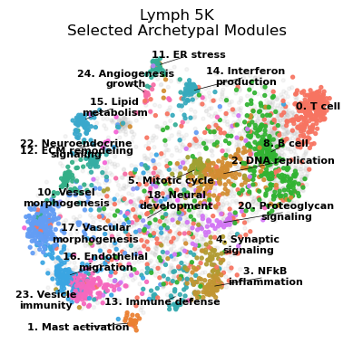

```python
ax = ecoton.plot_modules(G_ig, module_labels, nums, title='Lymph 5K\nSelected Archetypal Modules')
```

```python
workflow_res = [results, analytic_response, colocalization_response]
```

```python
import pickle
```

```python
#with open('processed_data/lymph_5k_workflow.pkl', 'wb') as f:
#    pickle.dump(workflow_res, f)
```

```python
transcripts = results['filtered_transcripts']
```

```python
coords = transcripts[['x_location', 'y_location']].values.astype(np.float32)
gene_labels = transcripts['feature_name'].values
```

```python
W_df = colocalization_response['W_df'] # where the full archetypes live
```

## top genes per archetype

a function for viewing top genes per archetype, by archetype weight

```
(<Figure size 200x500 with 1 Axes>,
 <Axes: title={'center': 'A8 Top Genes'}, xlabel='Weight'>)
```

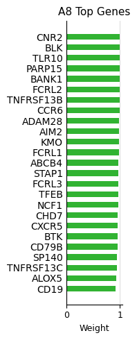

```python
ecoton.plot_gene_program_from_W(W_df, 8)
```

## continuous niche intensity maps

after computing archetypes, map them to space, getting niche intensities!

bin_size / smoothing_radius by default is 8 micrometers.

```python
len(results['genes'])
```

```
4602
```

```python
results['metatranscripts']
```

|  | feature_name | bin_x | bin_y | n | x_centroid | y_centroid | meta_id |
| --- | --- | --- | --- | --- | --- | --- | --- |
| 0 | AURKB | 92 | 408 | 3 | 737.411438 | 3266.005127 | 0 |
| 1 | AURKB | 90 | 419 | 3 | 724.234375 | 3355.229248 | 1 |
| 2 | AURKB | 92 | 413 | 4 | 740.210938 | 3310.621094 | 2 |
| 3 | AURKB | 91 | 414 | 3 | 732.973938 | 3317.942627 | 3 |
| 4 | AURKB | 92 | 414 | 3 | 738.307312 | 3315.807373 | 4 |
| ... | ... | ... | ... | ... | ... | ... | ... |
| 5121412 | REN | 200 | 243 | 5 | 1602.443726 | 1946.765625 | 5121412 |
| 5121413 | REN | 266 | 289 | 7 | 2131.975342 | 2315.718750 | 5121413 |
| 5121414 | REN | 480 | 96 | 3 | 3843.822998 | 770.276062 | 5121414 |
| 5121415 | REN | 480 | 583 | 3 | 3843.265625 | 4666.869629 | 5121415 |
| 5121416 | HRH3 | 593 | 417 | 3 | 4748.150879 | 3343.041748 | 5121416 |

5121417 rows × 7 columns

```python
mybin_size = mysmoothing_radius = 8.0
```

```python
niche_maps = ecoton.create_niche_maps_by_archetype_all_at_once(
        coords=coords,
        gene_labels=gene_labels,
        W=W_df,
        bin_size=mybin_size,
        smoothing_radius=mysmoothing_radius,
        weight_threshold=0.3,
)
```

```
--- Spatial Projection (Radius=8.0µm) ---
Grid size: 906 × 1056  (pixels=956736)
Archetypes: 25
Using union of driver genes: 3601 / 3997
```

Ecoton returns continuous, thresholdable maps of niche intensities. We show the continuous output per niche, and also show the top thresholded versions, at four standardized thresholds, which you can see shows how this continuous map behaves at increasingly strict categorical intensities.

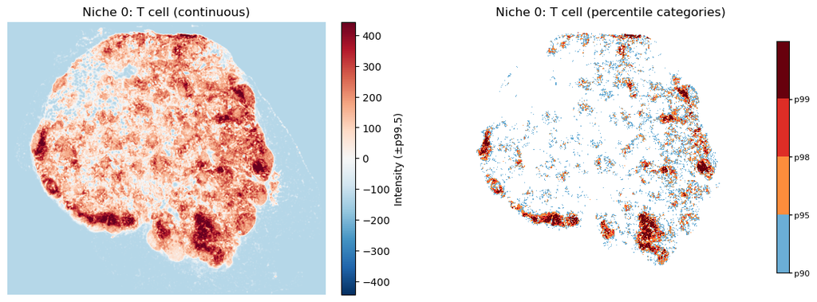

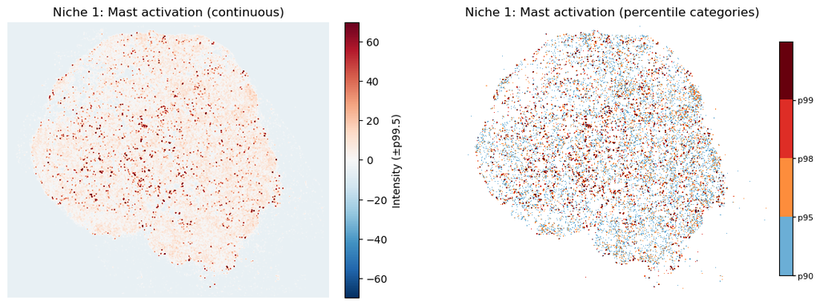

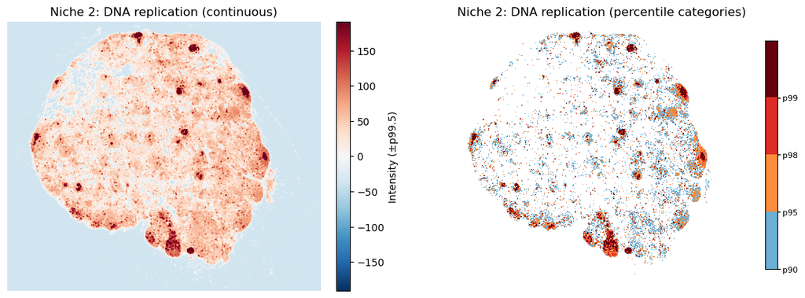

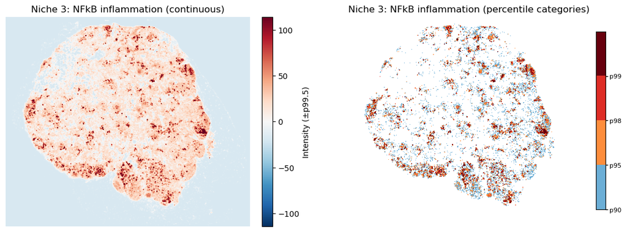

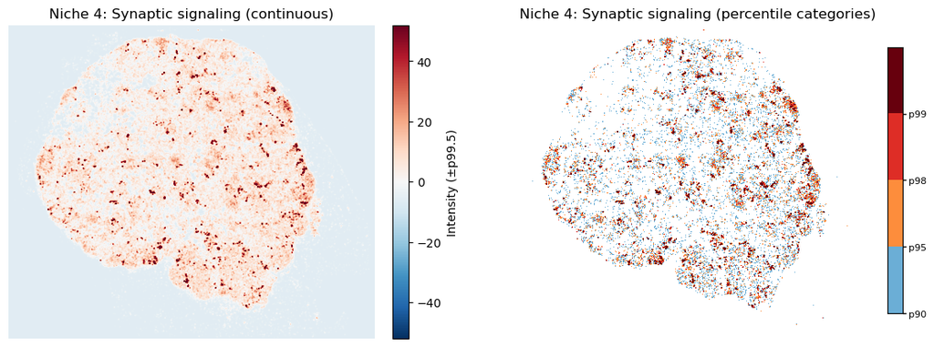

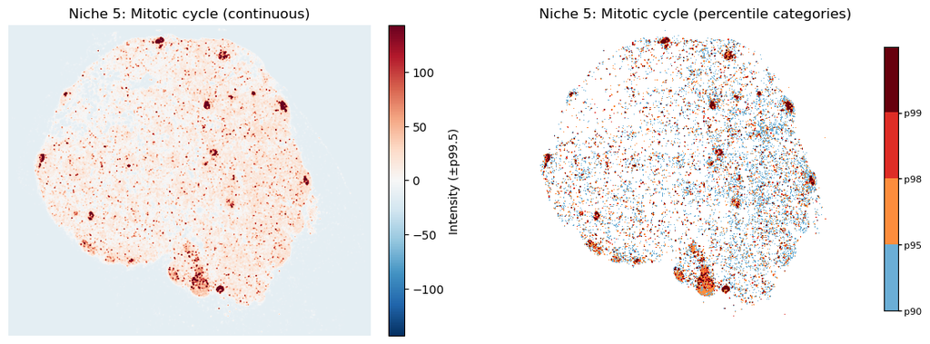

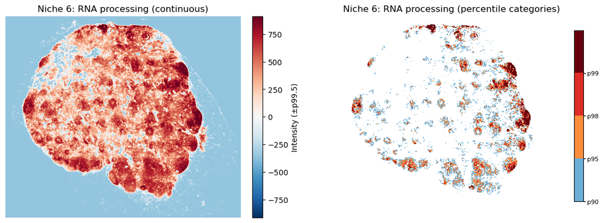

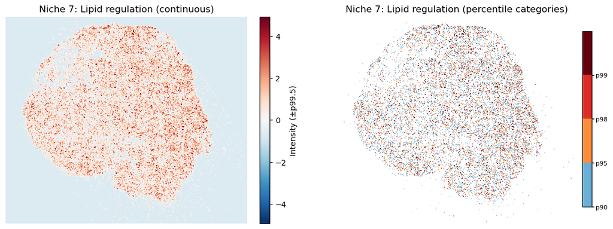

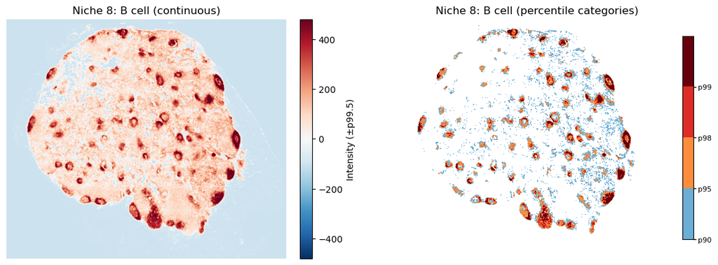

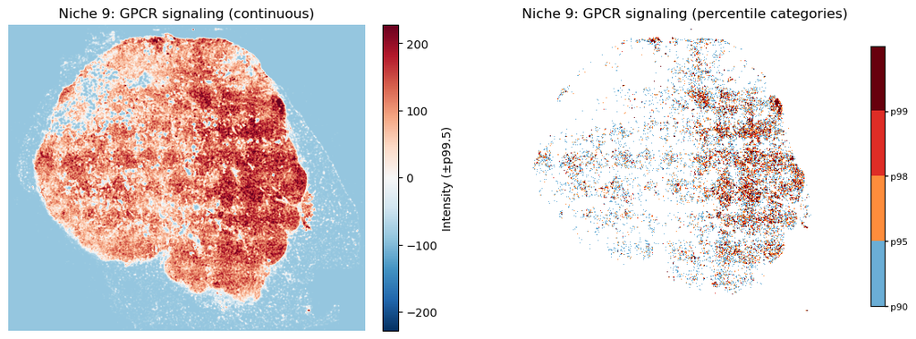

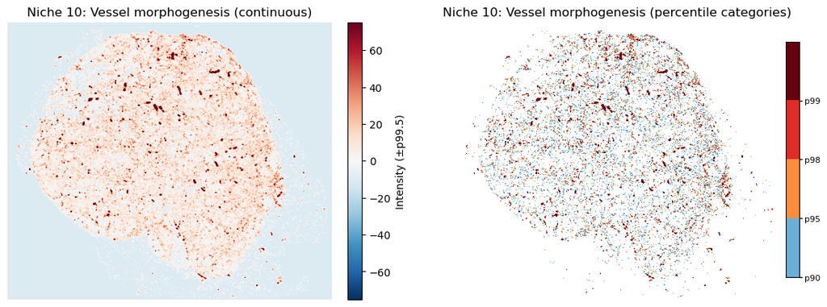

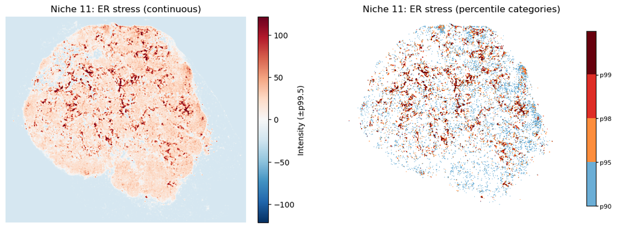

[13 more figures not shown]

```python
for k in range(25):
    ecoton.plot_niche_continuous_and_percentile_categories(niche_maps, k = k, module_labels=module_labels)
```

To probe the behavior of the niche intensities over the bins, we provide a knee-finding algorithm where four knees are found, each at a sharper intensity, as an alternative to the four standardized intensities.

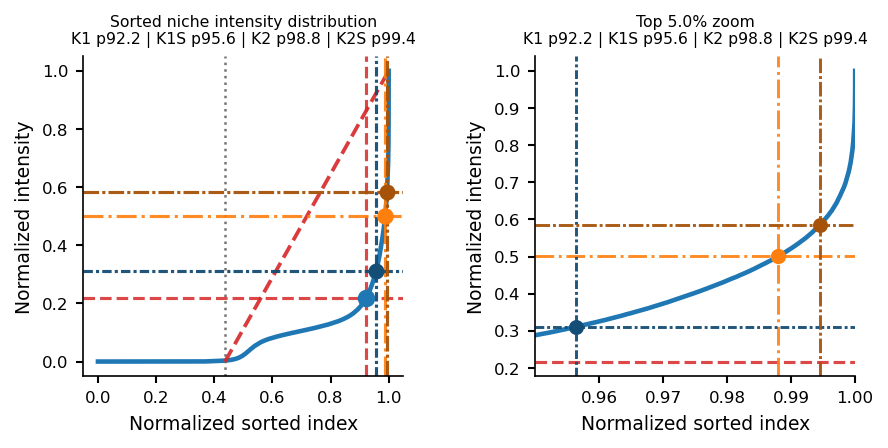

```python
thr, occ, info = ecoton.knee_from_sorted_curve(
    niche_maps[:, :,16],
    start_mode='auto',
    normalize_y=True,
    plot_top_zoom=True,
    zoom_top_fraction=0.05,
    sharper_first_knee_distance_fraction=0.95,
)
```

## bin transcripts and compute in cell / out of cell niche metrics

recompute binned transcripts, this time keeping track of transcripts in cells vs outside of cells (unassigned_tokens)

```python
resp = ecoton.bin_transcripts(
    transcripts,
    bin_size=mybin_size,
    x_col=results['x_coord'],
    y_col=results['y_coord'],
    cell_col="cell_id",
    gene_col=results["gene_name"],
    unassigned_tokens=("UNASSIGNED", -1),
    return_cells=True,
    return_matrix_split_assignment=True,  # <-- get X_split
    return_matrix=False,
    verbose=True,
)
```

```
============================================================
[bin_transcripts] starting
  df shape = (185424430, 13)
  return_matrix=False
  return_matrix_split_assignment=True
  return_cells=True
============================================================
[binning] computed bin_id
  bin_size = 8.0
  x range  = [5.656, 8443.422]
  y range  = [6.188, 7244.734]
  grid     = width=1056, height=906, P=956736
  n_transcripts = 185424430
[bin_transcripts] stored transcript_bin_ids mapping aligned to df.index
[cells] detected string cell ids
  n_assigned   = 175185126
  n_unassigned = 10239304
  unassigned_tokens = ('UNASSIGNED', -1)
[matrix_split] building bin x (gene|ASSIGNED + gene|UNASSIGNED) matrix...
[matrix_split] keep_empty_bins=False -> n_rows=550514 (compacted)
[matrix_split] done
  X_split shape = (550514, 9204) (bins x 2*genes)
  nnz           = 154980474
  n_genes       = 4602
  assigned block   = [:, 0:4602]
  unassigned block = [:, 4602:9204]
[cells_by_bin] building bin_counts and cells_by_bin...
[cells_by_bin] done
  present bins    = 550514
  bins w/ cells   = 471003
[bin_transcripts] finished
============================================================
```

```python
X_split = resp["X_split"]                # (n_rows, 2G)
bin_index = resp["bin_index_split"]      # row -> original bin_id
gene_names = resp["gene_names_split"]
grid_meta = resp["grid_meta"]
cells_by_bin = resp["cells_by_bin"]
G = len(gene_names)
```

```python
myniche= 12
```

```python
mythreshold = 'p98' # pick a binarizing threshold on the continuous map
```

```python
selected_bin_ids, mask, t = ecoton.bins_from_niche_threshold(
    niche_maps=niche_maps,
    grid_meta={**grid_meta, "height":niche_maps.shape[0], "width":niche_maps.shape[1]},
    k=myniche,
    threshold=mythreshold,
)

selected_bins = set(map(int, selected_bin_ids))

# rows of X_split whose original bin_id is in selected_bins
row_mask = np.isin(bin_index, list(selected_bins))
X_sel = X_split[row_mask, :]
```

```python
genes_of_interest = colocalization_response['modules_W'][myniche]
```

```python
import numpy as np

#genes_of_interest =   # your list of gene symbols (strings)

# --- map genes -> column indices in X_split
gene_to_idx = {g: i for i, g in enumerate(resp["gene_names_split"].astype(str))}
idx = np.array([gene_to_idx[g] for g in genes_of_interest if g in gene_to_idx], dtype=int)

if idx.size == 0:
    raise ValueError("None of your genes_of_interest were found in gene_names_split.")

G = len(resp["gene_names_split"])

# --- subset to niche bins (same row_mask you already made)
X_sel = resp["X_split"][row_mask, :]  # row_mask = bins in thresholded niche

# --- slice assigned/unassigned blocks for only those genes
assigned_ct   = X_sel[:, idx].sum()
unassigned_ct = X_sel[:, idx + G].sum()
total_ct      = assigned_ct + unassigned_ct

prop_unassigned = (unassigned_ct / total_ct) if total_ct != 0 else np.nan

print(f"genes requested: {len(genes_of_interest)}")
print(f"genes found:     {idx.size}")
print(f"assigned transcripts (subset):   {int(assigned_ct)}")
print(f"unassigned transcripts (subset): {int(unassigned_ct)}")
print(f"proportion unassigned (subset):  {prop_unassigned:.4%}")
```

```
genes requested: 40
genes found:     40
assigned transcripts (subset):   60051
unassigned transcripts (subset): 12536
proportion unassigned (subset):  17.2703%
```

the percentile returned above: this is the percent of transcripts inside the thresholded niche that is not within cells. Helpful for characterizing how much of this niche info is lost via segmentation and relying only on segmentation-downstream analyses.

[figure not shown]

```python
import matplotlib.pyplot as plt
import numpy as np
import seaborn as sns

# -----------------------------
# Archetype color (MATCH UMAP)
# -----------------------------
arch_ids = sorted(
    int(c.split("_")[-1]) for c in W_df.columns if c.startswith("archetype_")
)

cluster_order = [-1] + arch_ids   # same ordering used earlier
palette = sns.husl_palette(n_colors=len(cluster_order))
color_map = {cid: palette[i] for i, cid in enumerate(cluster_order)}

base_color = color_map[myniche]

# -----------------------------
# Data
# -----------------------------
assigned_ct = int(assigned_ct)
unassigned_ct = int(unassigned_ct)
total_ct = assigned_ct + unassigned_ct

prop_unassigned = unassigned_ct / total_ct if total_ct > 0 else np.nan

labels = ["Assigned\nto Cells", "Unassigned\nto Cells"]
values = [assigned_ct, unassigned_ct]

# -----------------------------
# Plot
# -----------------------------
fig, ax = plt.subplots(figsize=(3, 4))

bars = ax.bar(
    labels,
    values,
    color=[base_color, base_color],   # SAME color
    edgecolor="0.35",                 # helps hatch visibility
    linewidth=0.8
)

# Hatch ONLY the assigned bar
bars[0].set_hatch("///")

# Labels
ax.set_ylabel("Module Transcript Count")
ax.set_title(f"Transcript Assignment\nNiche {myniche}, 98% Threshold")

# Percent annotation
ax.text(
    x=1,
    y=unassigned_ct,
    s=f"{prop_unassigned:.1%}",
    ha="center",
    va="bottom",
    fontsize=11,
    fontweight="bold",
)

# Clean style
ax.spines["top"].set_visible(False)
ax.spines["right"].set_visible(False)

ax.yaxis.grid(True, linewidth=0.5, alpha=0.3)
ax.set_axisbelow(True)

plt.tight_layout()
plt.show()
```

### extracting the set of cells in the thresholded niche

```python
cells_subset = ecoton.cells_in_selected_bins(selected_bin_ids, cells_by_bin)

print(f"threshold used: {t:.4g}")
print(f"selected bins: {len(selected_bin_ids)}")
print(f"unique cells in selected bins: {len(cells_subset)}")
```

```
threshold used: 23.92
selected bins: 19135
unique cells in selected bins: 32053
```

can map the thresholded niche back to cells via the set extracted above.

```python
list(cells_subset)[:10]
```

```
['klhkeppk-1',
 'noilkaoi-1',
 'cmfpeigd-1',
 'ocijbgpa-1',
 'iehmabon-1',
 'gaokeile-1',
 'npgojghm-1',
 'jiaiamef-1',
 'jpaoimoj-1',
 'lafbgmhj-1']
```